# Nutritional Analysis showing relation between Macros and calories intake in Fast foods

### **3. Data Preview**

Data below is the original data containing all the values

```
## # A tibble: 515 x 17
##    restaurant item      calories cal_fat total_fat sat_fat trans_fat cholesterol
##    <chr>      <chr>        <dbl>   <dbl>     <dbl>   <dbl>     <dbl>       <dbl>
##  1 Mcdonalds  Artisan ~      380      60         7       2       0            95
##  2 Mcdonalds  Single B~      840     410        45      17       1.5         130
##  3 Mcdonalds  Double B~     1130     600        67      27       3           220
##  4 Mcdonalds  Grilled ~      750     280        31      10       0.5         155
##  5 Mcdonalds  Crispy B~      920     410        45      12       0.5         120
##  6 Mcdonalds  Big Mac        540     250        28      10       1            80
##  7 Mcdonalds  Cheesebu~      300     100        12       5       0.5          40
##  8 Mcdonalds  Classic ~      510     210        24       4       0            65
##  9 Mcdonalds  Double C~      430     190        21      11       1            85
## 10 Mcdonalds  Double Q~      770     400        45      21       2.5         175
## # ... with 505 more rows, and 9 more variables: sodium <dbl>, total_carb <dbl>,
## #   fiber <dbl>, sugar <dbl>, protein <dbl>, vit_a <dbl>, vit_c <dbl>,
## #   calcium <dbl>, salad <chr>
```

Data below is refined only for Chick - Fila Restuarant

```
## # A tibble: 27 x 17
##    restaurant  item     calories cal_fat total_fat sat_fat trans_fat cholesterol
##    <chr>       <chr>       <dbl>   <dbl>     <dbl>   <dbl>     <dbl>       <dbl>
##  1 Chick Fil-A Chargri~      430     144        16     8           0          85
##  2 Chick Fil-A Chargri~      310      54         6     2           0          55
##  3 Chick Fil-A Chick-n~      270      99        11     2.5         0          45
##  4 Chick Fil-A 1 Piece~      120      54         6     3           0          25
##  5 Chick Fil-A 2 Piece~      230     108        12     3           0          55
##  6 Chick Fil-A 3 Piece~      350     153        17     3           0          70
##  7 Chick Fil-A 4 piece~      470     207        23     3           0          90
##  8 Chick Fil-A Chicken~      500     207        23     7           0          75
##  9 Chick Fil-A 4 piece~      130      54         6     1.5         0          40
## 10 Chick Fil-A 6 piece~      190      81         9     1.5         0          55
## # ... with 17 more rows, and 9 more variables: sodium <dbl>, total_carb <dbl>,
## #   fiber <dbl>, sugar <dbl>, protein <dbl>, vit_a <dbl>, vit_c <dbl>,
## #   calcium <dbl>, salad <chr>
```

Data below is refined only for Mc_Donalds Restuarant

```
## # A tibble: 57 x 17
##    restaurant item      calories cal_fat total_fat sat_fat trans_fat cholesterol
##    <chr>      <chr>        <dbl>   <dbl>     <dbl>   <dbl>     <dbl>       <dbl>
##  1 Mcdonalds  Artisan ~      380      60         7       2       0            95
##  2 Mcdonalds  Single B~      840     410        45      17       1.5         130
##  3 Mcdonalds  Double B~     1130     600        67      27       3           220
##  4 Mcdonalds  Grilled ~      750     280        31      10       0.5         155
##  5 Mcdonalds  Crispy B~      920     410        45      12       0.5         120
##  6 Mcdonalds  Big Mac        540     250        28      10       1            80
##  7 Mcdonalds  Cheesebu~      300     100        12       5       0.5          40
##  8 Mcdonalds  Classic ~      510     210        24       4       0            65
##  9 Mcdonalds  Double C~      430     190        21      11       1            85
## 10 Mcdonalds  Double Q~      770     400        45      21       2.5         175
## # ... with 47 more rows, and 9 more variables: sodium <dbl>, total_carb <dbl>,
## #   fiber <dbl>, sugar <dbl>, protein <dbl>, vit_a <dbl>, vit_c <dbl>,
## #   calcium <dbl>, salad <chr>
```

Data below is refined only for Taco_Bell Restuarant

```
## # A tibble: 115 x 17
##    restaurant item      calories cal_fat total_fat sat_fat trans_fat cholesterol
##    <chr>      <chr>        <dbl>   <dbl>     <dbl>   <dbl>     <dbl>       <dbl>
##  1 Taco Bell  1/2 lb.*~      540     230        26       7         1          45
##  2 Taco Bell  1/2 lb.*~      460     170        18       7         1          45
##  3 Taco Bell  7-Layer ~      510     170        19       7         0          20
##  4 Taco Bell  Bean Bur~      370     100        11       4         0           5
##  5 Taco Bell  Beefy 5-~      550     200        22       8         0          35
##  6 Taco Bell  Beefy Fr~      440     160        18       5         0          20
##  7 Taco Bell  Black Be~      410     110        12       4         0          10
##  8 Taco Bell  Burrito ~      420     140        16       7         0          35
##  9 Taco Bell  Burrito ~      390     110        12       5         0          40
## 10 Taco Bell  Burrito ~      390     120        13       5         0          30
## # ... with 105 more rows, and 9 more variables: sodium <dbl>, total_carb <dbl>,
## #   fiber <dbl>, sugar <dbl>, protein <dbl>, vit_a <dbl>, vit_c <dbl>,
## #   calcium <dbl>, salad <chr>
```

Data below is refined only for subway Restuarant

```
## # A tibble: 96 x 17
##    restaurant item      calories cal_fat total_fat sat_fat trans_fat cholesterol
##    <chr>      <chr>        <dbl>   <dbl>     <dbl>   <dbl>     <dbl>       <dbl>
##  1 Subway     "6\" B.L~      320      80         9     4           0          20
##  2 Subway     "Footlon~      640     160        18     8           0          40
##  3 Subway     "6\" BBQ~      430     160        18     6           0          50
##  4 Subway     "Footlon~      860     320        36    12           0         100
##  5 Subway     "6\" Big~      580     310        31    11           0          85
##  6 Subway     "Footlon~     1160     620        62    22           0         170
##  7 Subway     "6\" Big~      500     150        17     9           1          85
##  8 Subway     "Footlon~     1000     300        34    18           2         170
##  9 Subway     "Kids Mi~      180      20         3     0.5         0          10
## 10 Subway     "6\" Bla~      290      40         5     1           0          20
## # ... with 86 more rows, and 9 more variables: sodium <dbl>, total_carb <dbl>,
## #   fiber <dbl>, sugar <dbl>, protein <dbl>, vit_a <dbl>, vit_c <dbl>,
## #   calcium <dbl>, salad <chr>
```

## Data Analysis

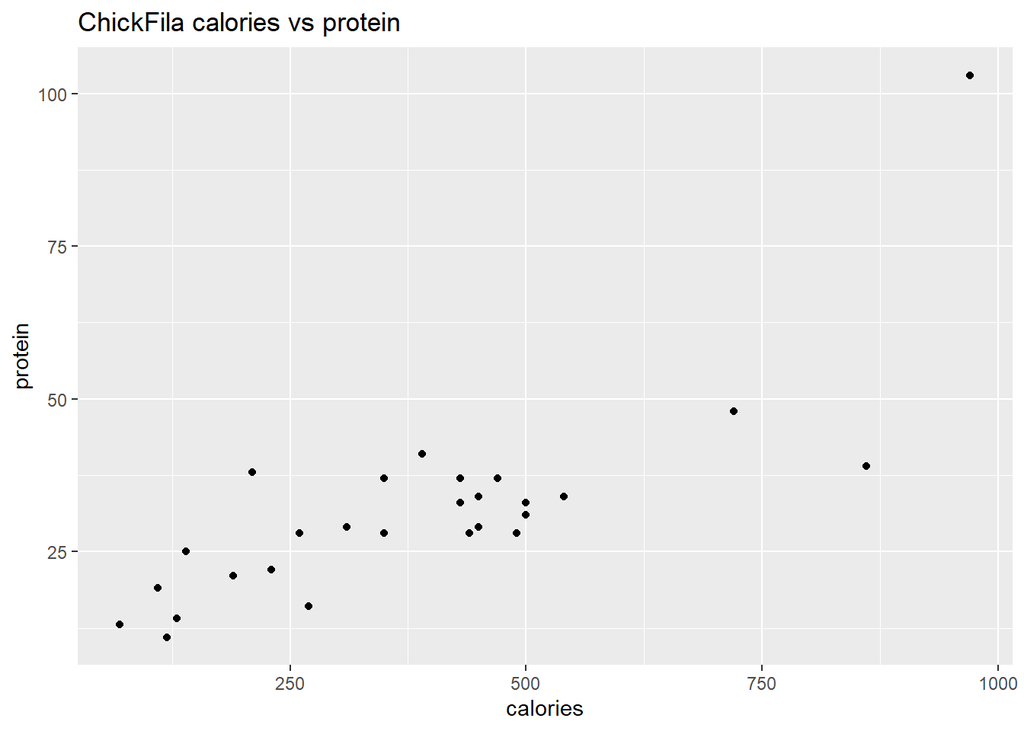

```r
ggplot(data = chickfila, aes(x = calories, y = protein)) + geom_point() + labs(title = 'ChickFila calories vs protein')
```

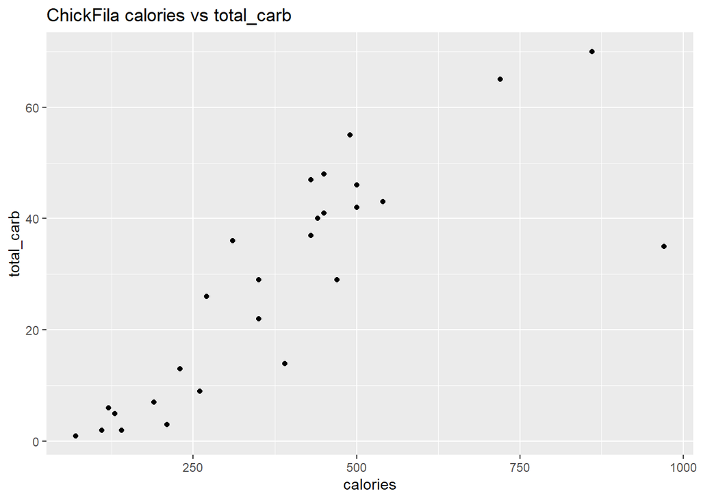

```r
ggplot(data = chickfila, aes( x = calories, y = total_carb)) + geom_point()+ labs(title = 'ChickFila calories vs total_carb')
```

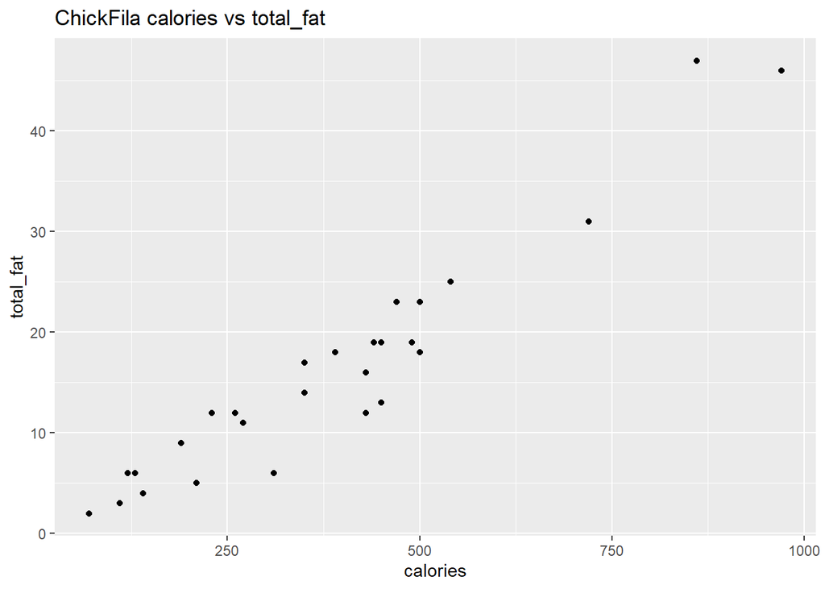

```r
ggplot(data = chickfila, aes( x = calories, y = total_fat)) + geom_point()+ labs(title = 'ChickFila calories vs total_fat')
```

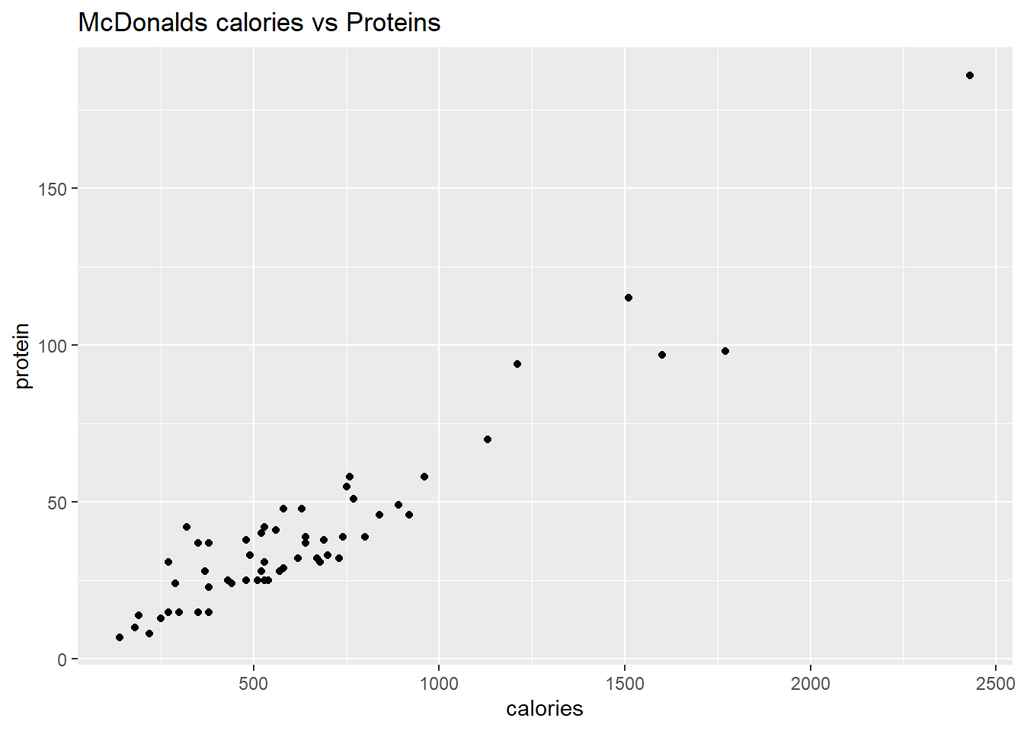

```r
ggplot(data = Mc_Donalds, aes(x = calories, y = protein)) + geom_point()+ labs(title = 'McDonalds calories vs Proteins')
```

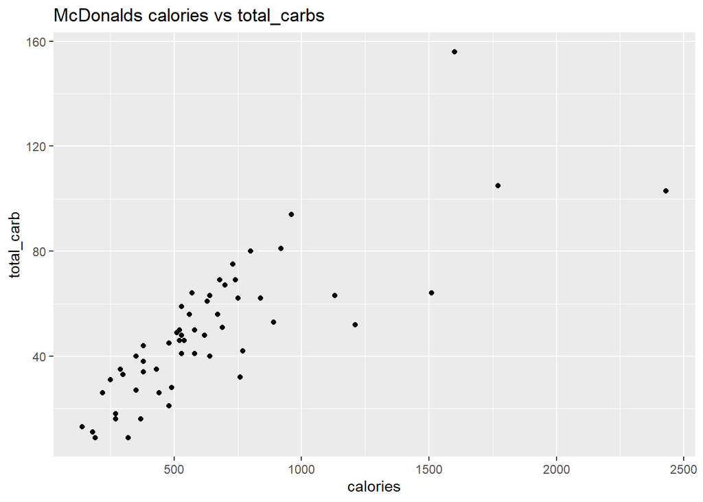

```r
ggplot(data = Mc_Donalds, aes( x = calories, y = total_carb)) + geom_point()+ labs(title = 'McDonalds calories vs total_carbs')
```

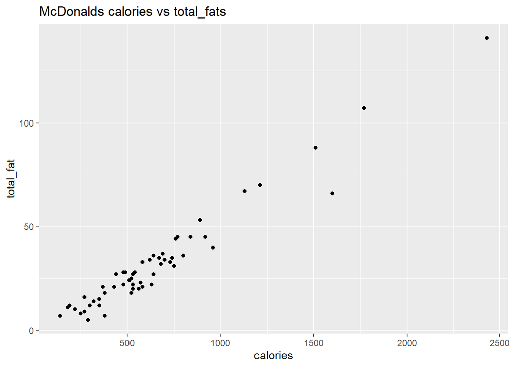

```r
ggplot(data = Mc_Donalds, aes( x = calories, y = total_fat)) + geom_point()+ labs(title = 'McDonalds calories vs total_fats')
```

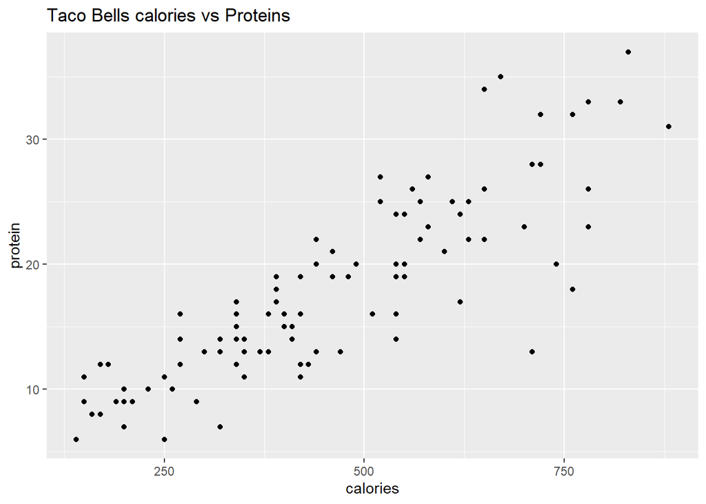

```r
ggplot(data = Taco_Bell, aes(x = calories, y = protein)) + geom_point()+ labs(title = 'Taco Bells calories vs Proteins')
```

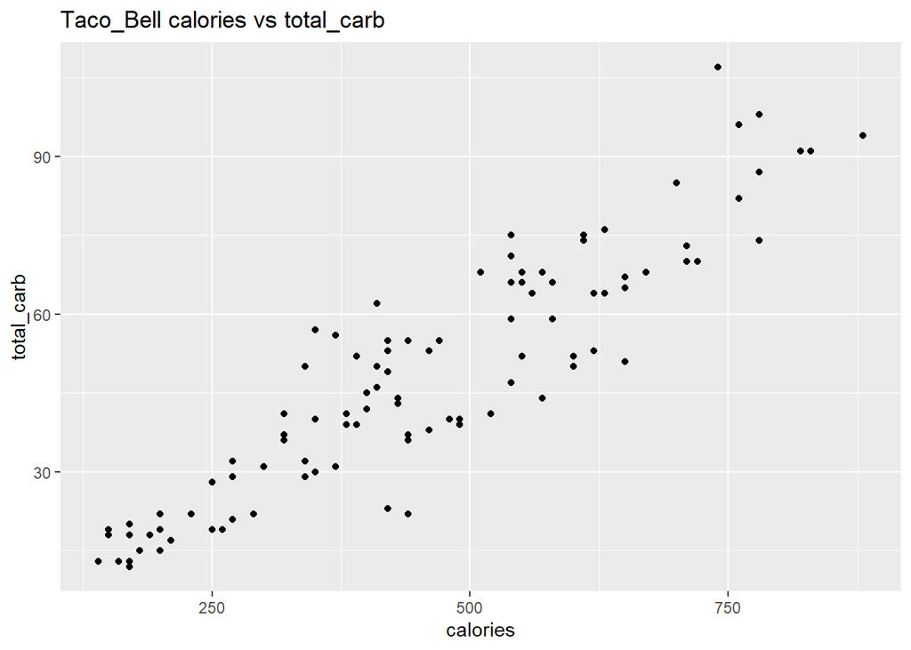

```r
ggplot(data = Taco_Bell, aes( x = calories, y = total_carb)) + geom_point()+ labs(title = 'Taco_Bell calories vs total_carb')
```

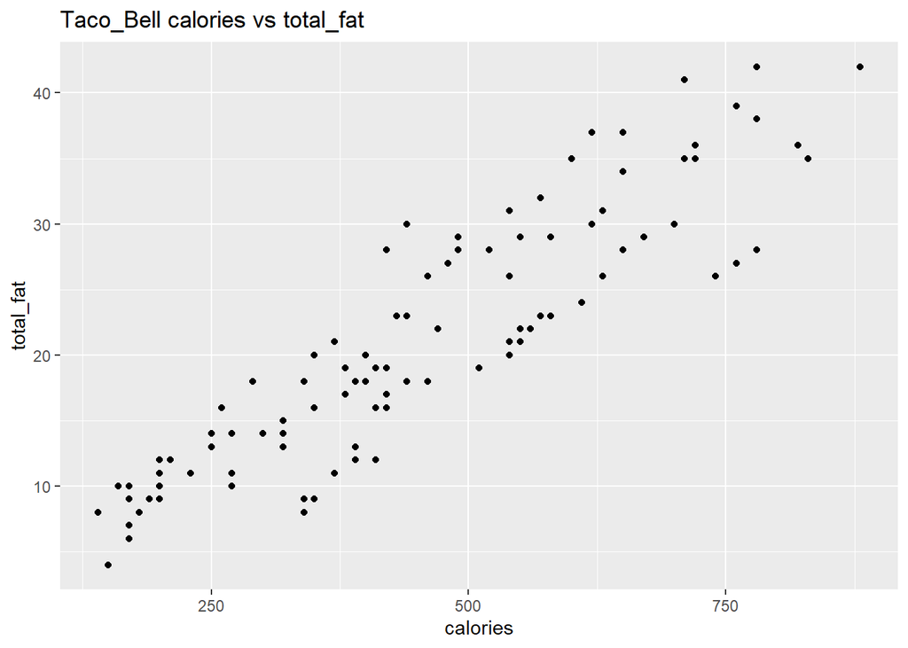

```r
ggplot(data = Taco_Bell, aes( x = calories, y = total_fat)) + geom_point()+ labs(title = 'Taco_Bell calories vs total_fat')
```

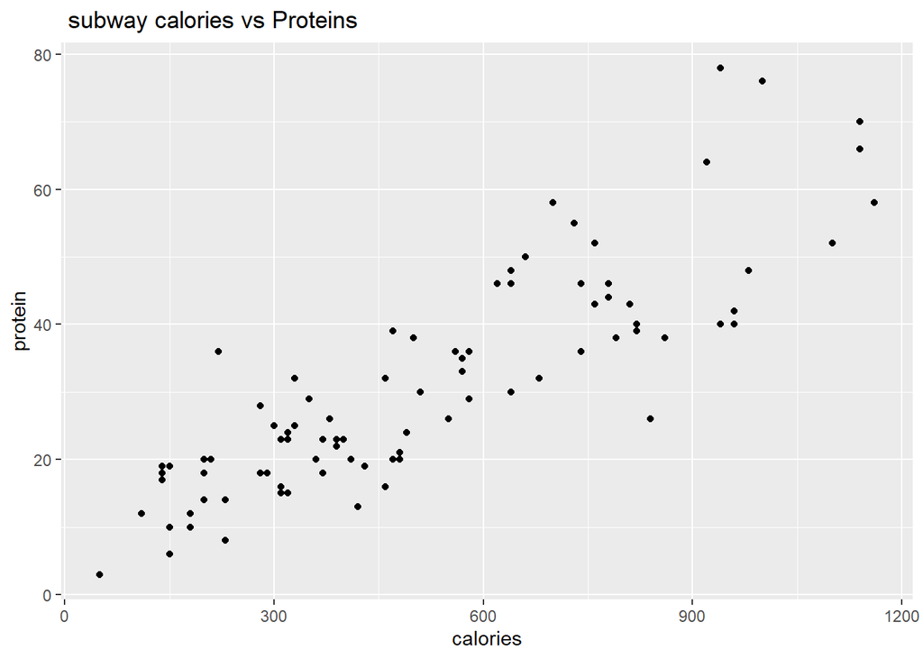

```r
ggplot(data = subway, aes(x = calories, y = protein)) + geom_point()+ labs(title =' subway calories vs Proteins')
```

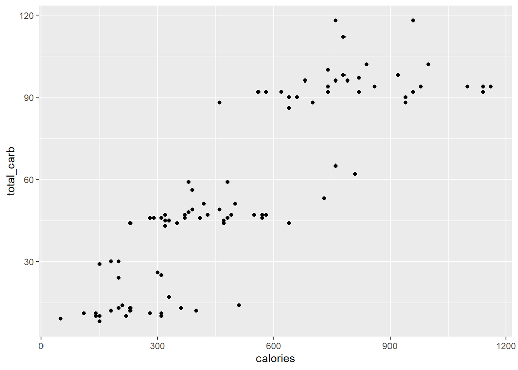

```r
ggplot(data = subway, aes( x = calories, y = total_carb)) + geom_point()+ labs('subway calories vs total_carb')
```

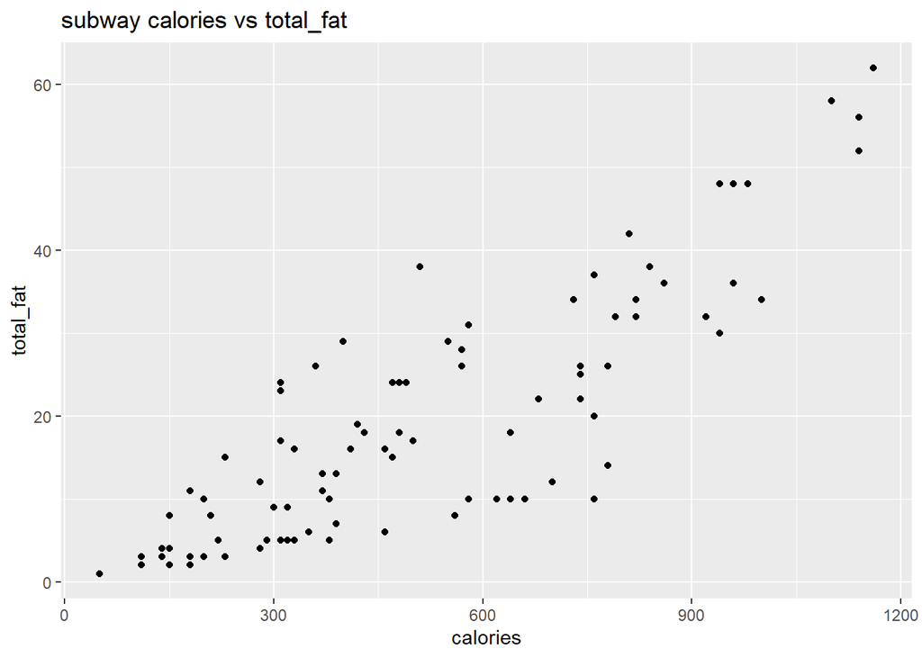

```r
ggplot(data = subway, aes( x = calories, y = total_fat)) + geom_point()+ labs(title = 'subway calories vs total_fat')
```

```r
#Normal Distribution
cfmean <- mean(chickfila$cal_fat)
cfmean
```

```
## [1] 145.3704
```

```r
cfsd   <- sd(chickfila$cal_fat)
cfsd
```

```
## [1] 102.3573
```

#Calculating the probability that an item in fastfood restaurants have more than 400 calories from fat

```r
#Calculating the probability that an item in fastfood restaurants have more than 400 calories from fat
subway <- fastfood %>%
  filter(restaurant == "Subway")

submean <- mean(subway$cal_fat)
subsd <- sd(subway$cal_fat)

1-pnorm(q = 400, mean = submean, sd = subsd)
```

```
## [1] 0.04074578
```

```r
chickmean <- mean(chickfila$cal_fat)
chicksd <- sd(chickfila$cal_fat)

1-pnorm(q = 400, mean = chickmean, sd = chicksd)
```

```
## [1] 0.006429412
```

```r
Mcmean <- mean(Mc_Donalds$cal_fat)
Mcsd <- sd(Mc_Donalds$cal_fat)

1-pnorm(q = 400, mean = Mcmean, sd = Mcsd)
```

```
## [1] 0.3022921
```

```r
Tacomean <- mean(Taco_Bell$cal_fat)
Tacosd <- sd(Taco_Bell$cal_fat)

1-pnorm(q = 400, mean = Tacomean, sd = Tacosd)
```

```
## [1] 0.006215318
```